# Final Project EDA

Yixiao Jiang & Shaohan Wang

April 5th, 2020

## Guiding Question

### What are the factors that might impact the spread of COVID-19 virus?

## Data Sources

```r
rm(list = ls())
library(readr)
library(DataComputing)
library(dplyr)
covid_19_data <- read_csv("covid_19_data.csv")
covid19_weather_data <- read.csv("covid19_weather_data.csv")
```

## Two Data Sources

### Primary data

covid_19_data: https://www.kaggle.com/sudalairajkumar/novel-corona-virus-2019-dataset

### Other data sources

covid19_weather_data: https://www.kaggle.com/hbfree/covid19formattedweatherjan22march24

## Become Acquainted with Data Sources

### 1. Where did you find them?

We obtained covid_19_data dataset from Kaggle. https://www.kaggle.com/sudalairajkumar/novel-corona-virus-2019-dataset The covid19_weather_data dataset is also from Kaggle. https://www.kaggle.com/hbfree/covid19formattedweatherjan22march24

### 2. Who collected/maintains them?

The covid_19_data dataset was extracted from the Johns Hopkins University and it continuously updates. The covid19_weather_data dataset was made with the weather data collected from World Weather Online API and was inspired by Weather Impact on COVID19 Spread by JHU.

### 3. When & Why were they originally collected?

This Coronavirus data is available from Jan. 22nd, 2020. It was collected to predict how and when the virus would end and provide timely condition of the spreading of the virus to the public. The covid19_weather_data is available from Jan. 22nd, 2020 and up to Mar. 24th, 2020 (60 days). It was collected to help understand of COVID19 and viral transmission by some important climate features.

### 4. What does a case represent in each data source, and how many total cases are available?

```r
# case of covid_19_data
nrow(covid_19_data)
```

```
[1] 11299
```

```r
# case of covid19_weather_data
nrow(covid19_weather_data)
```

```
[1] 18056
```

### 5. What are some of the variables that you plan to use?

```r
# inspect covid_19_data
ncol(covid_19_data)
```

```
[1] 8
```

```r
summary(covid_19_data)
```

```
      SNo        ObservationDate    Province/State     Country/Region     Last Update
 Min.   :    1   Length:11299       Length:11299       Length:11299       Length:11299
 1st Qu.: 2826   Class :character   Class :character   Class :character   Class :character
 Median : 5650   Mode  :character   Mode  :character   Mode  :character   Mode  :character
 Mean   : 5650
 3rd Qu.: 8474
 Max.   :11299
   Confirmed          Deaths           Recovered
 Min.   :     0   Min.   :    0.00   Min.   :    0.0
 1st Qu.:     3   1st Qu.:    0.00   1st Qu.:    0.0
 Median :    36   Median :    0.00   Median :    0.0
 Mean   :  1111   Mean   :   47.24   Mean   :  309.1
 3rd Qu.:   252   3rd Qu.:    2.00   3rd Qu.:   16.0
 Max.   :115242   Max.   :13915.00   Max.   :63471.0
```

```r
str(covid_19_data)
```

```
Classes ‘spec_tbl_df’, ‘tbl_df’, ‘tbl’ and 'data.frame':    11299 obs. of  8 variables:
 $ SNo            : num  1 2 3 4 5 6 7 8 9 10 ...
 $ ObservationDate: chr  "01/22/2020" "01/22/2020" "01/22/2020" "01/22/2020" ...
 $ Province/State : chr  "Anhui" "Beijing" "Chongqing" "Fujian" ...
 $ Country/Region : chr  "Mainland China" "Mainland China" "Mainland China" "Mainland China" ...
 $ Last Update    : chr  "1/22/2020 17:00" "1/22/2020 17:00" "1/22/2020 17:00" "1/22/2020 17:00" ...
 $ Confirmed      : num  1 14 6 1 0 26 2 1 4 1 ...
 $ Deaths         : num  0 0 0 0 0 0 0 0 0 0 ...
 $ Recovered      : num  0 0 0 0 0 0 0 0 0 0 ...
 - attr(*, "spec")=
  .. cols(
  ..   SNo = col_double(),
  ..   ObservationDate = col_character(),
  ..   `Province/State` = col_character(),
  ..   `Country/Region` = col_character(),
  ..   `Last Update` = col_character(),
  ..   Confirmed = col_double(),
  ..   Deaths = col_double(),
  ..   Recovered = col_double()
  .. )
```

```r
# inspect covid19_weather_data
ncol(covid19_weather_data)
```

```
[1] 22
```

```r
summary(covid19_weather_data)
```

```
          Province.State        Country.Region       lat              long
                 :9882   US            : 3416   Min.   :-41.45   Min.   :-157.498
 Diamond Princess: 122   China         : 2013   1st Qu.: 12.78   1st Qu.: -71.516
 Grand Princess  : 122   Canada        :  732   Median : 31.81   Median :  11.556
 Alabama         :  61   Australia     :  549   Mean   : 25.33   Mean   :   6.276
 Alaska          :  61   France        :  549   3rd Qu.: 42.18   3rd Qu.:  65.481
 Alberta         :  61   United Kingdom:  427   Max.   : 71.71   Max.   : 178.065
 (Other)         :7747   (Other)       :10370
      day          pop               urbanpop            density           medianage
 Min.   : 0   Min.   :8.010e+02   Min.   :     -999   Min.   : -999.00   Min.   :-999.0
 1st Qu.:15   1st Qu.:3.065e+06   1st Qu.:      351   1st Qu.: -249.75   1st Qu.:-237.0
 Median :30   Median :1.163e+07   Median :  5109464   Median :   59.00   Median :  32.0
 Mean   :30   Mean   :1.814e+08   Mean   :109645316   Mean   :   21.59   Mean   :-223.6
 3rd Qu.:45   3rd Qu.:4.559e+07   3rd Qu.: 30571144   3rd Qu.:  153.00   3rd Qu.:  40.0
 Max.   :60   Max.   :1.439e+09   Max.   :877987503   Max.   :26337.00   Max.   :  62.0

    smokers              tests           testpop       health_exp_pc     hospibed
 Min.   :     -999   Min.   :  -999   Min.   :  -999   Min.   :  17   Min.   :-999.00
 1st Qu.:     -999   1st Qu.:  -999   1st Qu.:  -999   1st Qu.: 224   1st Qu.:-249.53
 Median :   857410   Median :  -999   Median :  -999   Median : 426   Median :   2.70
 Mean   : 42142551   Mean   : 42721   Mean   :  3988   Mean   :1639   Mean   :-247.03
 3rd Qu.:  7180164   3rd Qu.: 11692   3rd Qu.:  1346   3rd Qu.:4026   3rd Qu.:   4.20
 Max.   :355512973   Max.   :320000   Max.   :415993   Max.   :9818   Max.   :  14.35
                                                       NA's   :5002
   quarantine        schools        restrictions     temperature        humidity
 Min.   :-999.0   Min.   :-999.0   Min.   :-999.0   Min.   :-47.00   Min.   :  5.00
 1st Qu.:-999.0   1st Qu.:-999.0   1st Qu.:-999.0   1st Qu.:  7.00   1st Qu.: 59.00
 Median :-999.0   Median :-999.0   Median :-999.0   Median : 17.00   Median : 75.00
 Mean   :-799.7   Mean   :-718.7   Mean   :-745.7   Mean   : 16.45   Mean   : 68.98
 3rd Qu.:-999.0   3rd Qu.:   0.0   3rd Qu.:   0.0   3rd Qu.: 27.00   3rd Qu.: 83.00
 Max.   :   1.0   Max.   :   1.0   Max.   :   1.0   Max.   : 46.00   Max.   :100.00

   confirmed           deaths          recovered
 Min.   :    0.0   Min.   :   0.00   Min.   :    0.0
 1st Qu.:    0.0   1st Qu.:   0.00   1st Qu.:    0.0
 Median :    0.0   Median :   0.00   Median :    0.0
 Mean   :  287.7   Mean   :  10.09   Mean   :  104.3
 3rd Qu.:    9.0   3rd Qu.:   0.00   3rd Qu.:    0.0
 Max.   :67800.0   Max.   :5476.00   Max.   :59433.0
```

```r
str(covid19_weather_data)
```

```
'data.frame':   18056 obs. of  22 variables:
 $ Province.State: Factor w/ 133 levels "","Alabama","Alaska",..: 1 1 1 1 1 1 1 1 1 1 ...
 $ Country.Region: Factor w/ 171 levels "Afghanistan",..: 1 1 1 1 1 1 1 1 1 1 ...
 $ lat           : num  33 33 33 33 33 33 33 33 33 33 ...
 $ long          : num  65 65 65 65 65 65 65 65 65 65 ...
 $ day           : int  0 1 2 3 4 5 6 7 8 9 ...
 $ pop           : int  38928346 38928346 38928346 38928346 38928346 38928346 38928346 38928346 38928346 38928346 ...
 $ urbanpop      : int  9732086 9732086 9732086 9732086 9732086 9732086 9732086 9732086 9732086 9732086 ...
 $ density       : int  60 60 60 60 60 60 60 60 60 60 ...
 $ medianage     : int  18 18 18 18 18 18 18 18 18 18 ...
 $ smokers       : num  -999 -999 -999 -999 -999 -999 -999 -999 -999 -999 ...
 $ tests         : int  -999 -999 -999 -999 -999 -999 -999 -999 -999 -999 ...
 $ testpop       : num  -999 -999 -999 -999 -999 -999 -999 -999 -999 -999 ...
 $ health_exp_pc : int  60 60 60 60 60 60 60 60 60 60 ...
 $ hospibed      : num  0.5 0.5 0.5 0.5 0.5 0.5 0.5 0.5 0.5 0.5 ...
 $ quarantine    : int  -999 -999 -999 -999 -999 -999 -999 -999 -999 -999 ...
 $ schools       : int  -999 -999 -999 -999 -999 -999 -999 -999 -999 -999 ...
 $ restrictions  : int  -999 -999 -999 -999 -999 -999 -999 -999 -999 -999 ...
 $ temperature   : int  4 4 4 6 5 5 3 4 4 5 ...
 $ humidity      : int  75 63 92 84 62 62 47 40 35 38 ...
 $ confirmed     : int  0 0 0 0 0 0 0 0 0 0 ...
 $ deaths        : int  0 0 0 0 0 0 0 0 0 0 ...
 $ recovered     : int  0 0 0 0 0 0 0 0 0 0 ...
```

For covid_19_data, there are a total of 8 variables, and we planned to use “Country/Region”, “Deaths”, and “Recovered” to discover the research question. For covid19_weather_data, there are a total of 22 variables, and we planned to use “lat”, “long”, “temperature” and “humidity” to proceed and solve the project questions.

## Intuition Related to Research Question

### 1. Create some informative plots and summary statistics

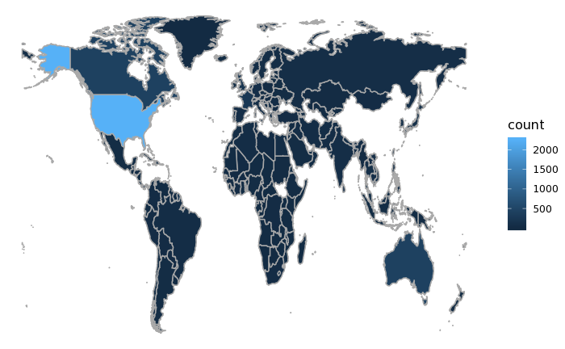

```r
# covid_19_data
NewData <- covid_19_data[ ,c(4,7,8)]
# Create data table grouped by country
SummaryStats <-
  NewData %>%
  group_by(`Country/Region`) %>%
  summarise(count = n(), death = sum(ifelse(Deaths == 0, 0, 1)), recovered = sum(ifelse(Recovered == 0, 0, 1)))
# plots using world map
WorldMap(SummaryStats, key = `Country/Region`, fill = count)
```

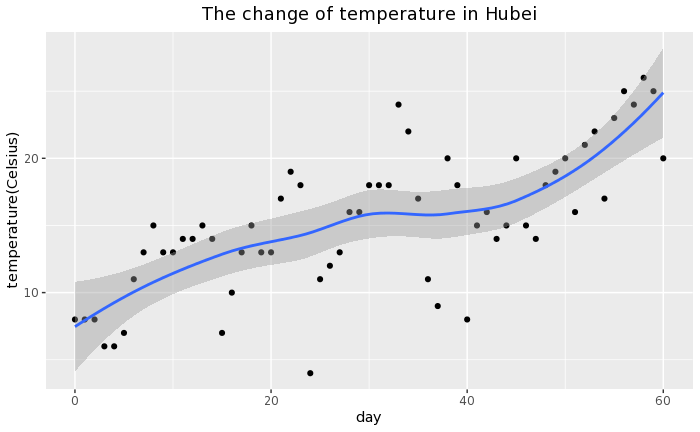

```r
# covid19_weather_data
# Create data table grouped by province/state
DataTable_Hubei <-
  covid19_weather_data %>%
  filter(Province.State == 'Hubei') # Hubei of China
DataTable_NewYork <-
  covid19_weather_data %>%
  filter(Province.State == 'New York') # New York State of United States
# Data Visualization of the change of temperature in Hubei of China
DataTable_Hubei %>%
  ggplot(aes(x = day, y = temperature)) +
  geom_point() +
  geom_smooth(method = "loess") +
  ylab('temperature(Celsius)') +
  ggtitle('The change of temperature in Hubei') +
  theme(plot.title = element_text(hjust = 0.5))
```

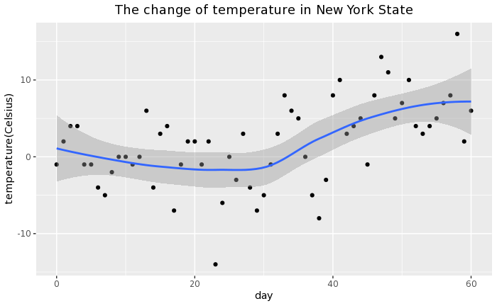

```r
# Data Visualization of the change of temperature in New York State of United States
DataTable_NewYork %>%
  ggplot(aes(x = day, y = temperature)) +
  geom_point() +
  geom_smooth(method = "loess") +
  ylab('temperature(Celsius)') +
  ggtitle('The change of temperature in New York State') +
  theme(plot.title = element_text(hjust = 0.5))
```

### 2. Describe preliminary observations and intuition about the research question

Some factors contributed to the spread of COVID-19 virus might deal with the corresponding humidity and weather temperature in those regions.